# LaBB-CAT

Setting Up a Corpus

Robert Fromont

3 December 2024

## LaBB-CAT needs:

### Transcripts

- `what`: Orthographic *transcripts* (audio/video is optional)
- `when`: …divided into time-stamped *utterances* (≤ 15 words)
- `who`: …with some way to identify the *speaker*

Textual data is supported

- *Transcript* = text
- *Utterances* = lines
- *Speaker* = author

## Transcript Formats

- Praat TextGrid

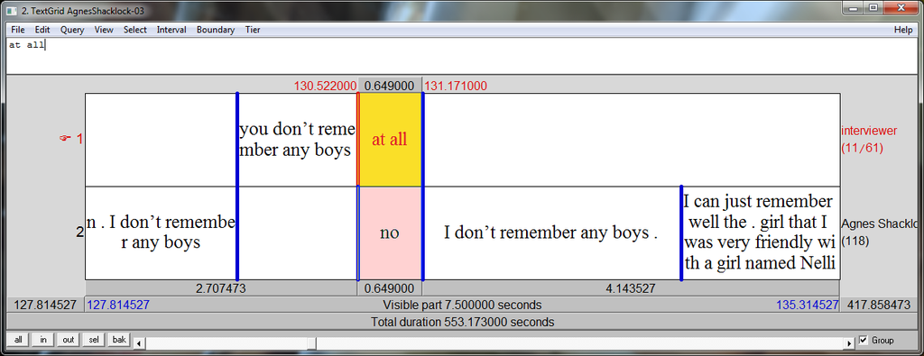

One tier per speaker

## Transcript Formats

- Praat TextGrid

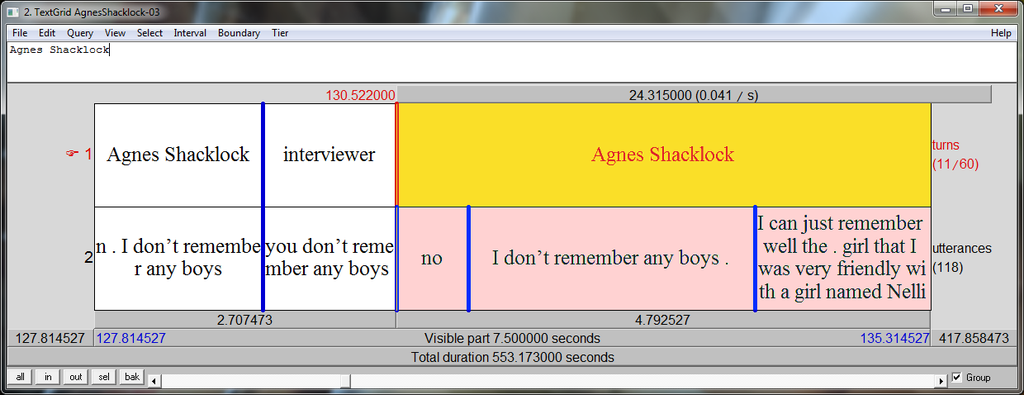

One tier per layer

## Transcript Formats

- Praat TextGrid
- Transcriber

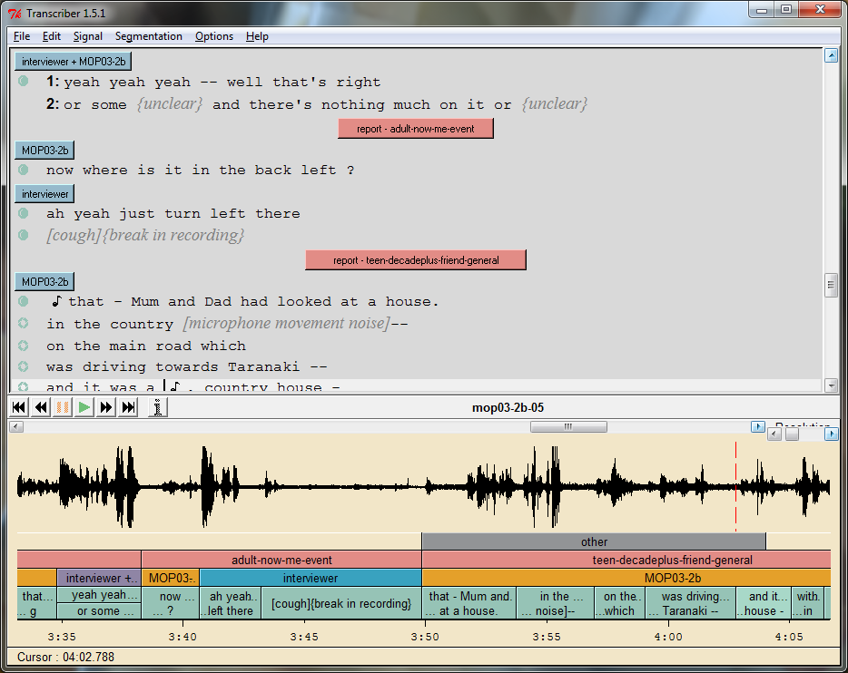

## Transcript Formats

- Praat TextGrid
- Transcriber
- ELAN

[figure not shown]

## Transcript Formats

- Praat TextGrid
- Transcriber
- ELAN
- Plain Text

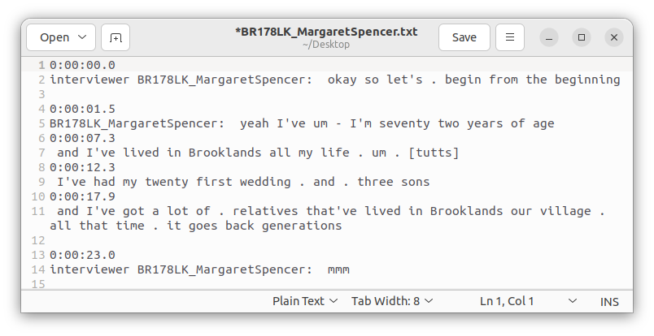

## Transcript Formats

- Praat TextGrid
- Transcriber
- ELAN
- Plain Text
- CHAT (partial support)

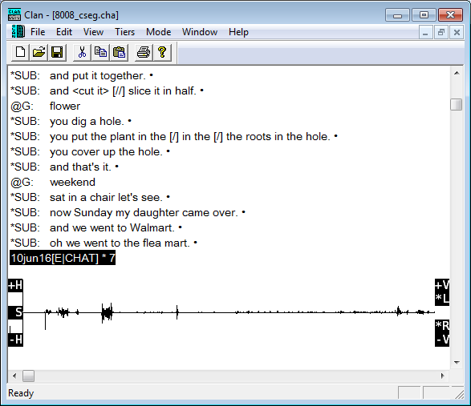

## Transcript Formats

- Praat TextGrid
- Transcriber
- ELAN
- Plain Text
- CHAT (partial support)
- SALT (partial support)

## Transcript Formats

- Praat TextGrid
- Transcriber
- ELAN
- Plain Text
- CHAT (partial support)
- SALT (partial support)
- TEI (partial support)

## Transcript Formats

- Praat TextGrid
- Transcriber
- ELAN
- Plain Text
- CHAT (partial support)
- SALT (partial support)
- TEI (partial support)
- VTT Subtitles

## Elicitation Tasks

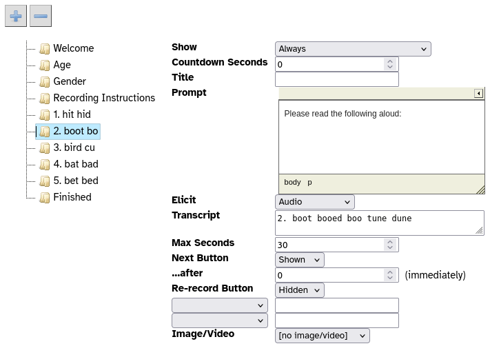

Define a speech elicitation task

## Elicitation Tasks

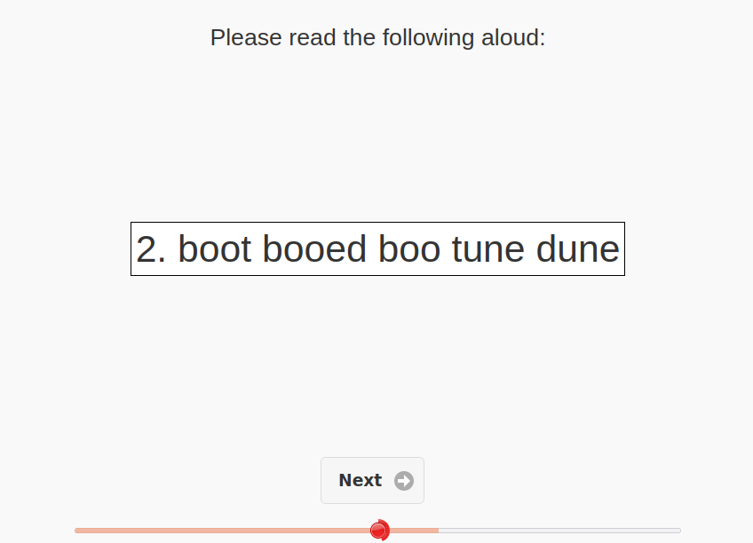

Recording via the web browser

## Meta-data

Both *Transcripts* and *Participants* can have defined ‘attributes’

- Textual types:
  - **String** - e.g. ethnicity
  - **Text** - e.g. notes
  - **Email** - e.g. contact address
  - **URL** - e.g. source document
  - **Read Only** - e.g. transcript version
- Numeric types:
  - **Integer** - e.g. age in years
  - **Number** - e.g. syllables per minute
  - Styles: *Slider* - e.g. rating
- Temporal types:
  - **Date** - e.g. date of birth
  - **Time** - e.g. interview duration
  - **Date/Time** - e.g. recording date/time
- Fixed class types:
  - **Boolean** e.g. checked
  - **Select** e.g. language  
    Styles:
    - *Multiple* - e.g. permissions
    - *Other* - e.g. gender

## Client/Server

[figure not shown]

Browser on Clients

[figure not shown]

[figure not shown]

Web Server

## Standalone

[figure not shown]

Browser and Web Server on the same computer

## Layer Managers

#### Automated Annotation

- Porter Stemmer – English stem
- Lexicon layer managers: CELEX, CMU Dictionary, Unisyn, Flat file dictionary
- Pattern Matcher and Character Mapper – regular-expression-based processing
- Frequency – word counts in different scopes
- LIWC – percentages of words in different categories
- Statistics – aggregation od groups of tokens
- Context – previous mention, previous pause
- Partition – partitions of n tokens
- Javascript and Python managers – arbitrary scripting
- **Stanford POS Tagger** – part-of-speech
- Stanford Parser – syntactic parsing
- Forced alignment …

## Forced Alignment

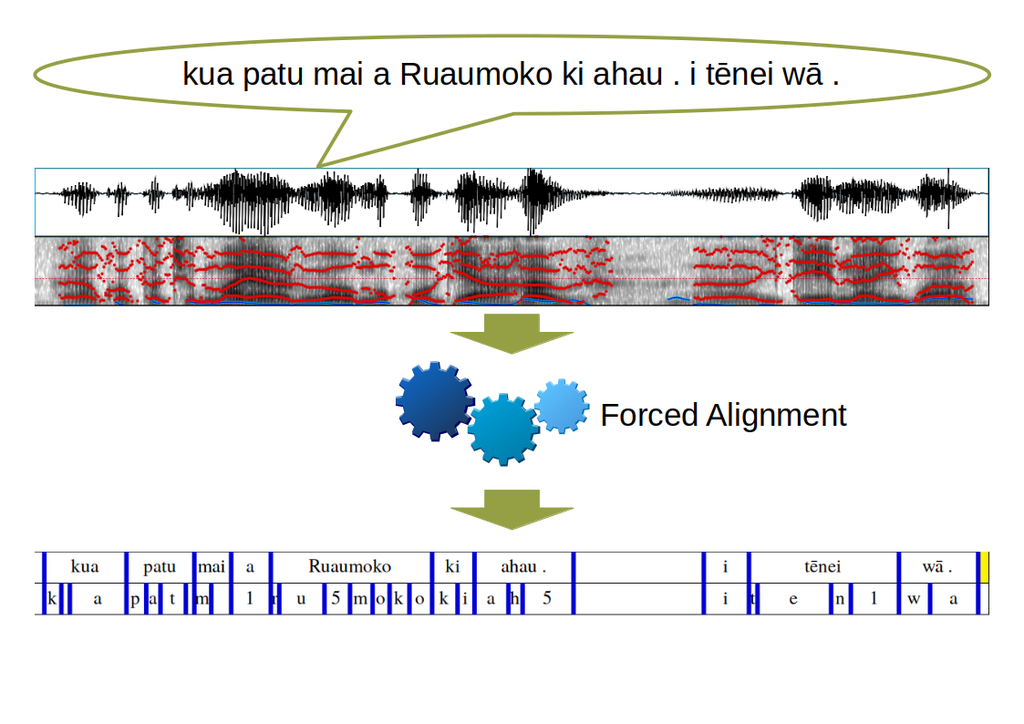

Automatically locate start/end times of speech sounds

## HTK / Penn Aligner

[figure not shown]

HTK software, Penn pretrained models

## Montreal Forced Aligner

[figure not shown]

MFA software, Dictionaries and pretrained models downloaded from GitHub

## WebMAUS

[figure not shown]

Transcripts and recordings sent over the internet

## LaBB-CAT

- Open Source
- Cross Platform
- Free to install  
  https://sourceforge.net/projects/labbcat

robert.fromont@canterbury.ac.nz

https://labbcat.canterbury.ac.nz

## Worksheets…

[figure not shown]

Create a corpus from ELAN transcripts